# ch8. Interpolation and Geostatistics

차서연

Sep 6, 2020

### 8.2 Exploratory Data Analysis

```r
## package installation
library(lattice)
library(sp)
```

- relationship between zink concentration & distance to the river

```r
data(meuse)
head(meuse)
```

```
##        x      y cadmium copper lead zinc  elev       dist   om ffreq soil
## 1 181072 333611    11.7     85  299 1022 7.909 0.00135803 13.6     1    1
## 2 181025 333558     8.6     81  277 1141 6.983 0.01222430 14.0     1    1
## 3 181165 333537     6.5     68  199  640 7.800 0.10302900 13.0     1    1
## 4 181298 333484     2.6     81  116  257 7.655 0.19009400  8.0     1    2
## 5 181307 333330     2.8     48  117  269 7.480 0.27709000  8.7     1    2
## 6 181390 333260     3.0     61  137  281 7.791 0.36406700  7.8     1    2
##   lime landuse dist.m
## 1    1      Ah     50
## 2    1      Ah     30
## 3    1      Ah    150
## 4    0      Ga    270
## 5    0      Ah    380
## 6    0      Ga    470
```

```r
# assign coordinates
coordinates(meuse) <- c("x","y")
```

- Zinc concentration을 공간 위에 그린 그림:
- `spplot()`: spatial data plotting

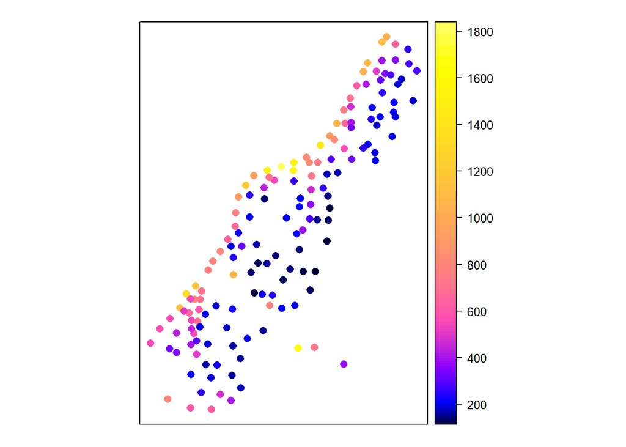

```r
par(mfrow = c(1,2))
# plotting it in 2 ways
spplot(meuse, "zinc", do.log = T, colorkey = TRUE)
```

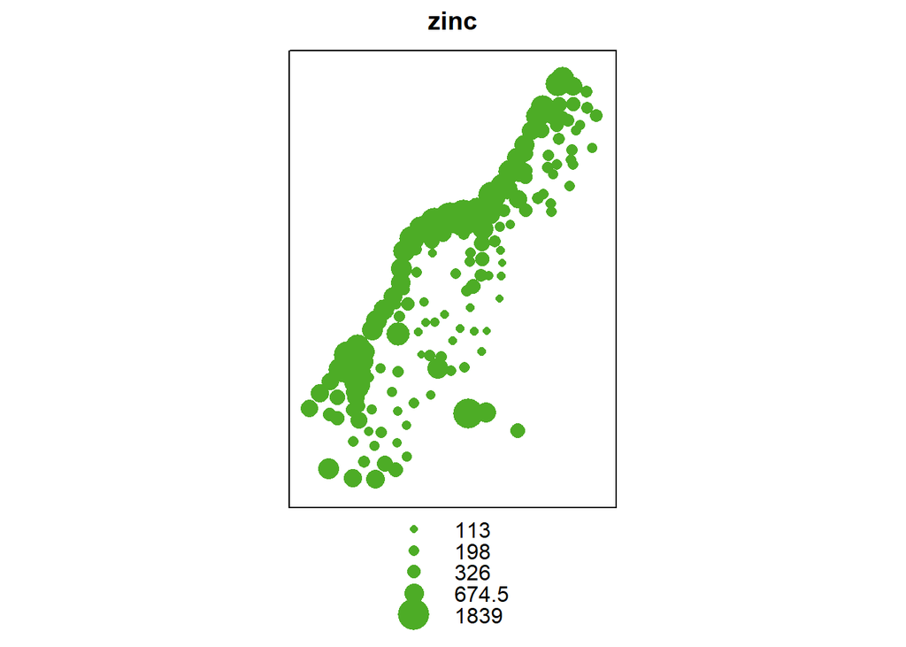

```r
bubble(meuse, "zinc", do.log = T, key.space = "bottom")
```

- Zinc 농도와 거리 간의 관계를 알고 싶다.
- 반비례 관계가 발견된다.

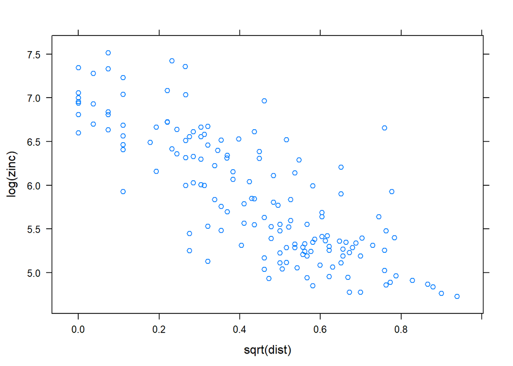

```r
# relation between zinc concentration and distance to the river
xyplot(log(zinc) ~ sqrt(dist), as.data.frame(meuse))
```

- Use `lm()` function for regression.

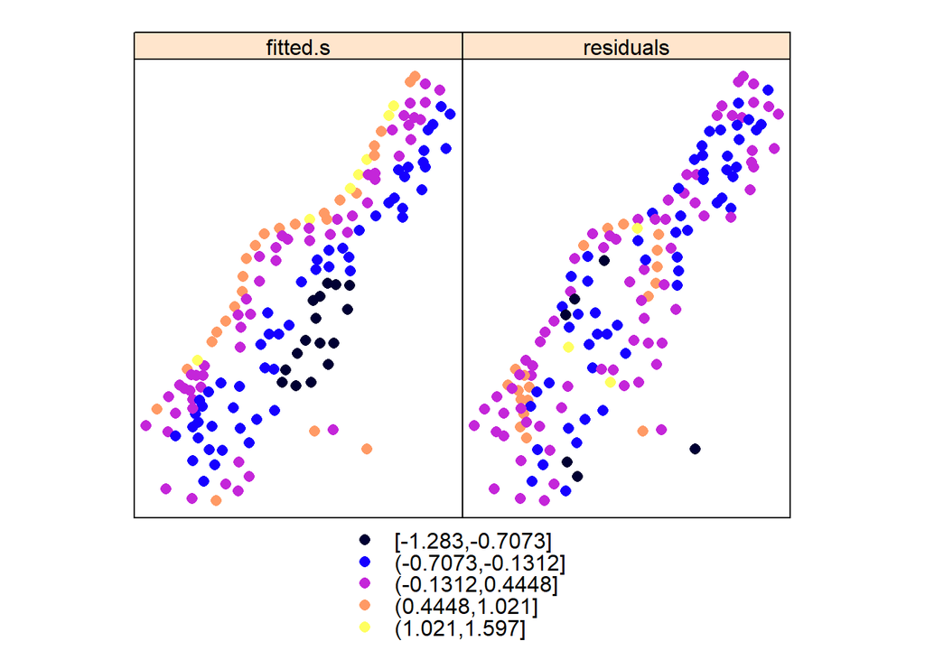

```r
zn.lm <- lm(log(zinc) ~ sqrt(dist), meuse)
meuse$fitted.s <- predict(zn.lm, meuse) - mean(predict(zn.lm, meuse))
meuse$residuals <- residuals(zn.lm)
spplot(meuse, c("fitted.s", "residuals"))
```

- Residuals -> seems spatially correlated, it is not a white noise.
- Residuals with a similar value occur regularly close to another.

### 8.3 Non-geostatistical Interpolation Methods

- interpolation is done on a regular grid.

```r
data(meuse.grid) # provides coordinate points on a regular grid
head(meuse.grid)
```

```
##        x      y part.a part.b      dist soil ffreq
## 1 181180 333740      1      0 0.0000000    1     1
## 2 181140 333700      1      0 0.0000000    1     1
## 3 181180 333700      1      0 0.0122243    1     1
## 4 181220 333700      1      0 0.0434678    1     1
## 5 181100 333660      1      0 0.0000000    1     1
## 6 181140 333660      1      0 0.0122243    1     1
```

```r
coordinates(meuse.grid) <- c("x","y") # assign a coordinate
meuse.grid <- as(meuse.grid, "SpatialPixelsDataFrame") # convert data.frame into a SpatialPixelsDataFrame
```

### 8.3.1 Inverse Distance Weighted Interpolation

#### IDW(Inverse Distance Weighted Interpolation)

- computes a weighted average
- interpolation on $s_0$, considering distances by computing weight

$$\hat{Z(s_0) = \frac{\sum_{i=1}^{n}w(s_i)Z(S_i)}{\sum_{i=1}^{n}w(s_i)}}$$
,

- weights are computed according to thier distance to the interpolation location,

$$w(s_i)$ =||s_i - s_0||^{-p}$$

- p: inverse distance weighting power로, distant point 에 비해 nearer point를 얼마나 더 prefer할 거냐의 정도를 결정하는데, (보통 2)
- p 값이 클수록 가까운 점에 더 weight 많이 준다.
  - for larger values, IDW converges to the one nearest neighbor interpolation

```r
library(gstat)
idw.out <- gstat::idw(zinc ~ 1, meuse, meuse.grid, idp = 2.5) # idp = 2.5
```

```
## [inverse distance weighted interpolation]
```

```r
as.data.frame(idw.out)[1:5,]
```

```
##        x      y var1.pred var1.var
## 1 181180 333740  701.9621       NA
## 2 181140 333700  799.9616       NA
## 3 181180 333700  723.5780       NA
## 4 181220 333700  655.3131       NA
## 5 181100 333660  942.0218       NA
```

```r
# var1.pred, var1.var(=NA, becuase inverse distance does not provide prediction error variances)
```

#### Compared to Kriging

- IDW only considers distances to the prediction. It ignores spatial configuration
- This may lead to undesired effects if the observation locations are strongly clustered
- weight $w(s_i)$ value are guaranteed to be on (0,1), so that interpolated values never outside the range of observed values

### 8.3.2 Linear Regression

- Linear Regression for spatial prediction using `lm()`.

```r
zn.lm <- lm(log(zinc) ~ sqrt(dist), meuse)
meuse.grid$pred <- predict(zn.lm, meuse.grid)
```

- as no variogram is specified, `krige()` yields a same result.

```r
## krige function
meuse.lm <- krige(log(zinc) ~ sqrt(dist), meuse, meuse.grid)
```

```
## [ordinary or weighted least squares prediction]
```

#### trend surface analysis: predictor - polynomials of spatial coordinates

- 좌표를 통한 polynomial로 grid point 추정
- a method based on low-order polynomials of spatial coordinates for estimating a regular grid of points from scattered obs.

```r
## polynomial regression
meuse.tr2 <- krige(log(zinc) ~ 1, meuse, meuse.grid,
                   degree = 2)
## equivalently, using lm ftn
lm(log(zinc) ~ I(x^2) + I(y^2) + I(x*y)+x+y, meuse)
#or
lm(log(zinc) ~ poly(x,y, degree = 2), meuse)
```

### 8.4 Estimating Spatial Correlation: The Variogram

- **Variogram**(semivariogram) for modelling spatial correlation.
  - variogram plots semivariance as a function of distance
- To estimate spatial correlation between two locations, given only a single pair observation, we need stationarity assumption
- *intrinsic stationarity*
  - constant mean. $Z(s) = m + e(s)$,
  - $\gamma(h) = \frac{1}{2}E(Z(s) - Z(s+h))^2$
  - does not depend on location $s$, we can form *multiple* pairs.
- furthermore, *isotropy*: direction independence of semivariance
- 거리 h인 여러 pair를 방향에 관계없이 모아서 variogram 계산 가능.
- **sample variogram**
  $$\hat{\gamma}(\tilde{h_j}) = \frac{1}{2N_h} \sum_{i=1}^{N_h} (Z(s_i) - Z(s_i + h))^2, \forall \in \tilde{h_j}$$
- mean varying model: mean varies spatially

### 8.4.1 Exploratory Variogram Analysis

- Explore spatial correlation is present or not

**1.** Plotting scatter plot use `hscat()` - make scatter plots of pairs $Z(s_i) , Z(s_j)$, grouped by the distance $h_{ij} = ||s_i - s_j||$

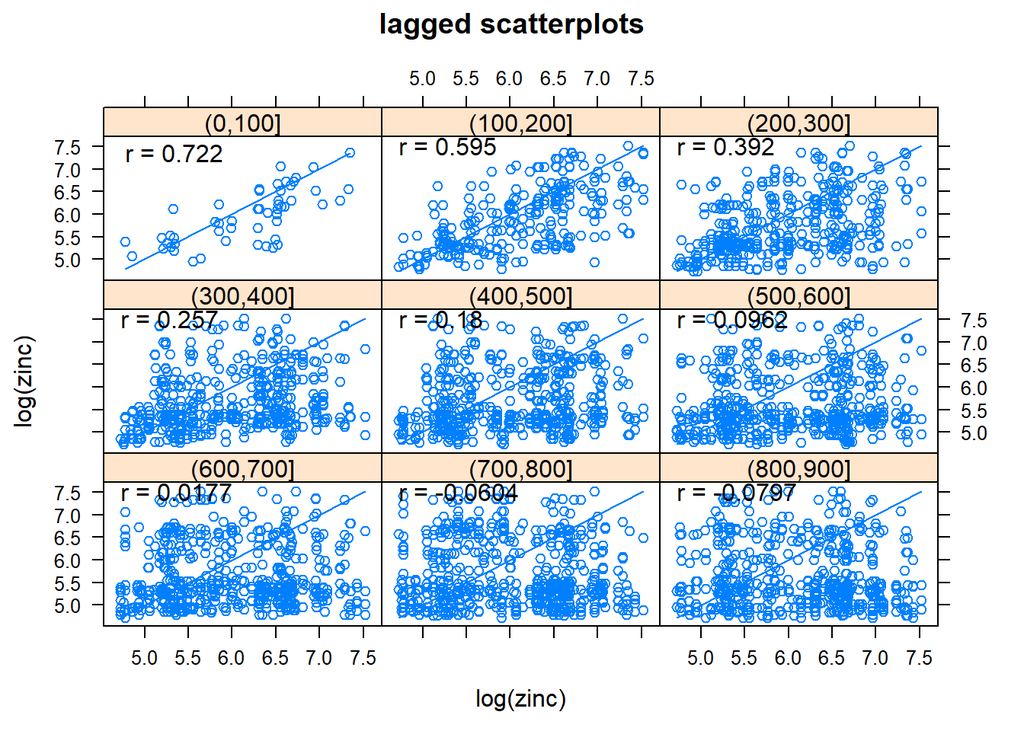

```r
# Produce h-scatterplot
hscat(log(zinc) ~ 1, meuse, (0:9) *100) # grouped according to their distances
```

```r
#up to distance 900, divided by 9 intervals.
```

- 거리가 짧을수록 표본상관계수 값이 높은 경향

**2.** Plotting the variogram and the variogram cloud * variogram cloud plots all possible squared differneces of obs. pairs $(Z(s_i)-Z(s_j))^2$ against their separation distance $h_{ij}$ * when $Z(s)$ follows Gaussian, $(Z(s_i)-Z(s_j))^2$ follows a $\chi^2(1)$ distn.

- compute variogram using `variogram()` ftn: .

```r
cld <- variogram(log(zinc) ~ 1, meuse, cloud = TRUE) # ~1: spatially constant mean coefficient
svgm <- variogram(log(zinc) ~ 1, meuse)
head(cld) # computes gamma for each distance
```

```
##        dist       gamma dir.hor dir.ver   id left right
## 1  70.83784 0.006065804       0       0 var1    2     1
## 2 118.84864 0.109534743       0       0 var1    3     1
## 3 141.56624 0.167153095       0       0 var1    3     2
## 4 259.23927 0.952808244       0       0 var1    4     1
## 5 282.85155 1.110920725       0       0 var1    4     2
## 6 143.17123 0.416229664       0       0 var1    4     3
```

```r
head(svgm) # np: # of points
```

```
##    np      dist     gamma dir.hor dir.ver   id
## 1  57  79.29244 0.1234479       0       0 var1
## 2 299 163.97367 0.2162185       0       0 var1
## 3 419 267.36483 0.3027859       0       0 var1
## 4 457 372.73542 0.4121448       0       0 var1
## 5 547 478.47670 0.4634128       0       0 var1
## 6 533 585.34058 0.5646933       0       0 var1
```

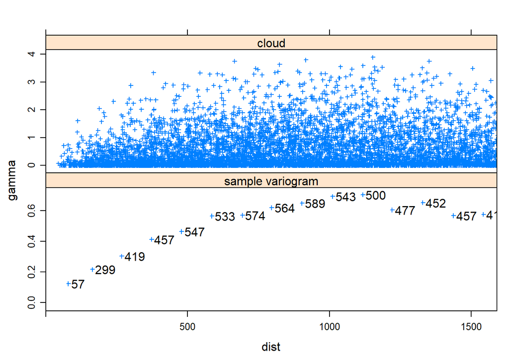

```r
d <- data.frame(gamma = c(cld$gamma, svgm$gamma),
    dist = c(cld$dist, svgm$dist),
    id = c(rep("cloud", nrow(cld)), rep("sample variogram", nrow(svgm)))
    )
xyplot(gamma ~ dist | id, d,
    scales = list(y = list(relation = "free",
      #ylim = list(NULL, c(-.005,0.7)))),
      limits = list(NULL, c(-.005,0.7)))),
    layout = c(1, 2), as.table = TRUE,
    panel = function(x,y, ...) {
        if (panel.number() == 2)
            ltext(x+10, y, svgm$np, adj = c(0,0.5)) #$
        panel.xyplot(x,y,...)
    },
    xlim = c(0, 1590),
    cex = .5, pch = 3
)
```

- 거리에 따른 sample variogram. 여기서는 1500/100 = 15(width)개의 점
- plot of averages of semivariogram cloud values over distance intervals $h$.

#### Verify whether these increase in semivariance with distance is out of chance

- 거리에 따른 semivariance의 증가가 spatial correlation이 아닌 단순 우연에 의했을 가능성 체크
- 같은 데이터를 가지고 randomly re-assigning 하여 variogram 그리기

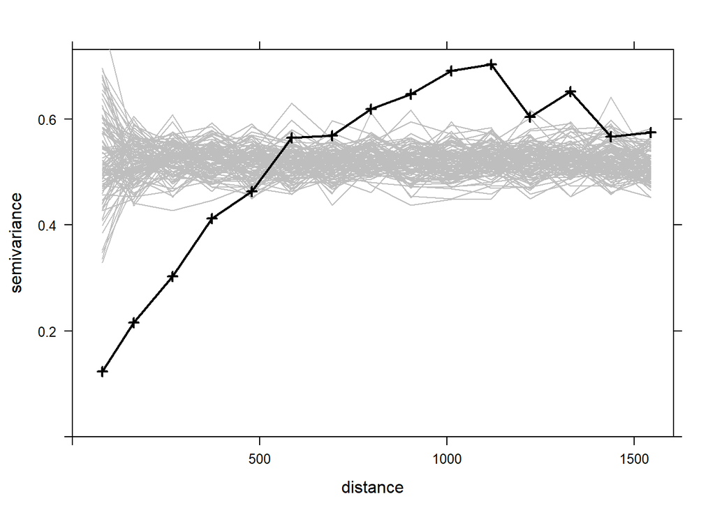

```r
v <- variogram(log(zinc) ~ 1, meuse)
#INTERACTIVE mode out-commented:
plot(v, type = 'b', pch = 3)
fn = function(n = 100) {
       for (i in 1:n) {
          meuse$random = sample(meuse$zinc)
          v = variogram(log(random) ~ 1, meuse)
          trellis.focus("panel", 1, 1, highlight = FALSE)
          llines(v$dist, v$gamma, col = 'grey')
          trellis.unfocus()
       }
}
fn()
trellis.focus("panel", 1, 1, highlight = FALSE)
lpoints(v$dist, v$gamma, col = 'black', type = 'b', lwd = 2, pch=3)
```

- grey : variograms for randomly re-allocated data
- our sample variogram does not include in this region, so that we reject the possibility of complete spatial randomness

#### Directional sample variogram with `alpha()` (include angle information)

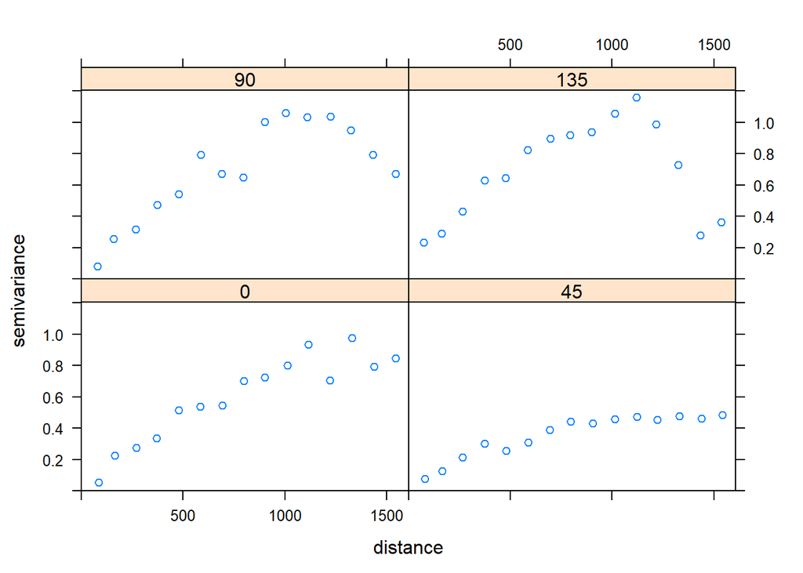

```r
plot(variogram(log(zinc)~1, meuse, alpha = (0:3)*45))
```

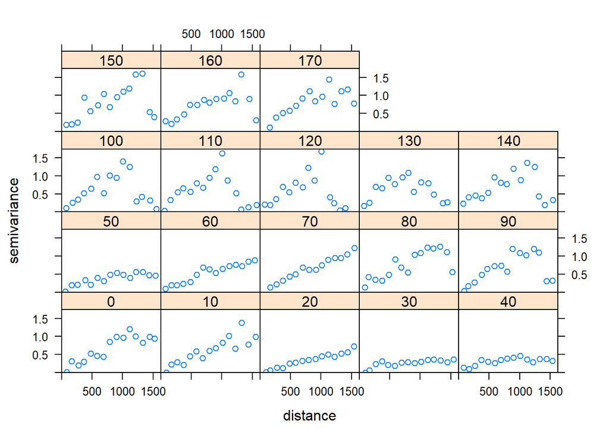

```r
plot(variogram(log(zinc) ~ 1, meuse, alpha = seq(0,170,10))) # noise increase, as number of data decr.
```

#### Adjust cutoff, width

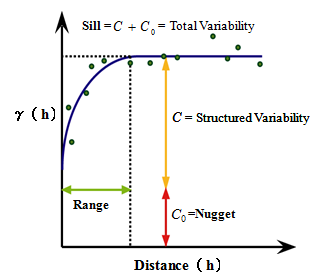

Variogram model

- cutoff: maximum distance
- width: width of distance interval (bin size) (usually cutoff/15)

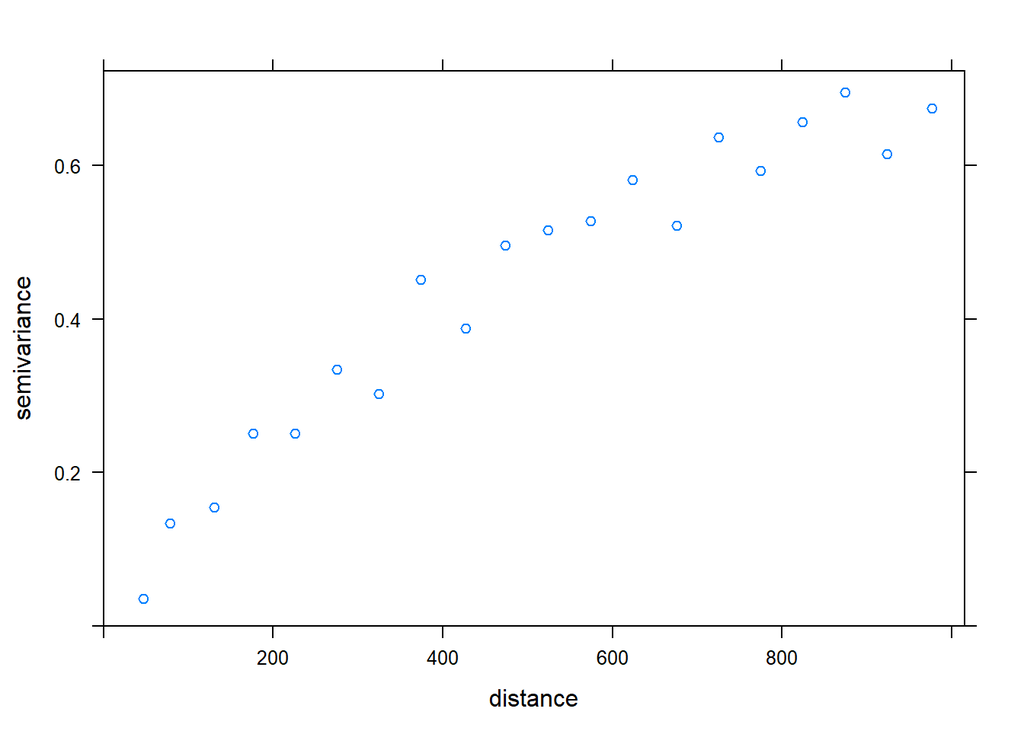

```r
plot(variogram(log(zinc) ~ 1, meuse, cutoff=1000, width=50)) #1000/50=20, 20points appear
```

- we can also specify irregular interval
- can zoom on the short distance variogram

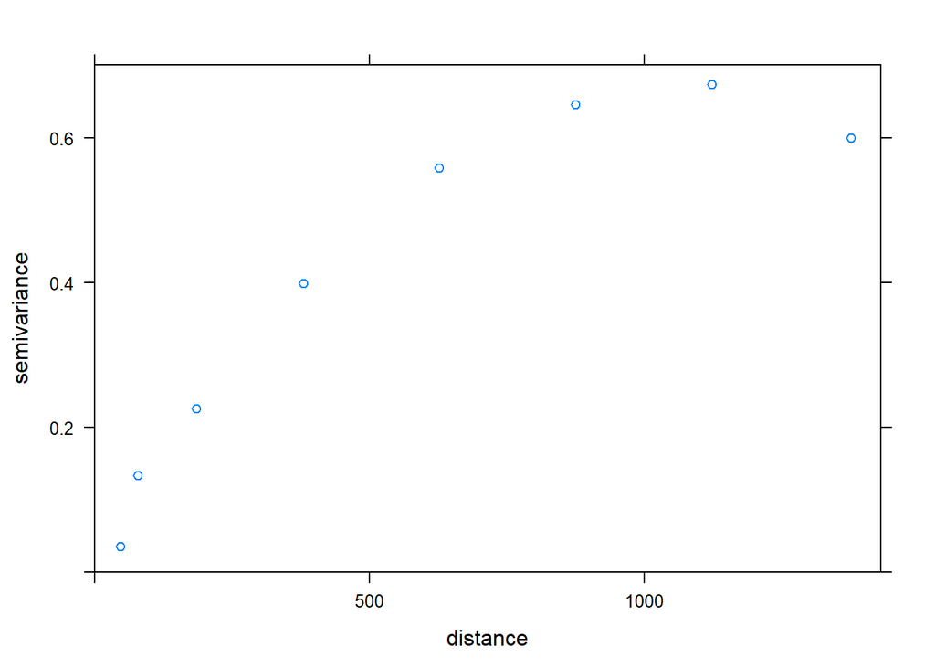

```r
# or we can set non-regular intervals
plot(variogram(log(zinc) ~ 1, meuse, boundaries = c(0,50,100, seq(250,1500,250))))
```

### 8.4.3 Variogram Modelling

- variogram 은 spatial prediction, simulation에 쓰일 수 있다.
- Have to ensure that predictions are associated with non-negative definite prediction variances
- Modeling 시 단순히 sample variogram value를 plugging-in 하면 matrix 의 non-negative 를 보장 못함.
- For this, infer a **parametric variogram model** from the data.
- Also, there is a non-parametric way, using smoothing and cutting off negative frequencies in the spectral domain.
- Fit parametric model to the sample variogram
- Some variogram parametric Models are:

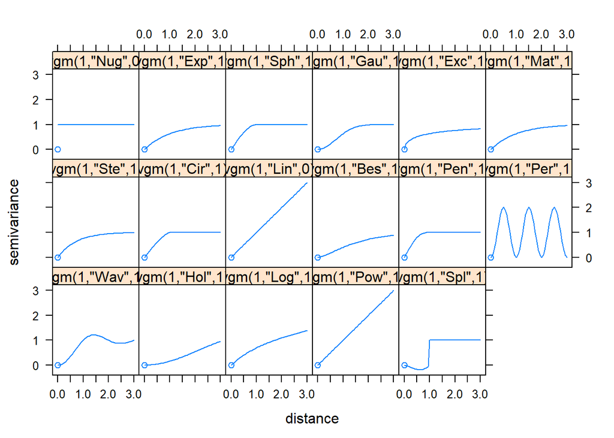

```r
show.vgms()
```

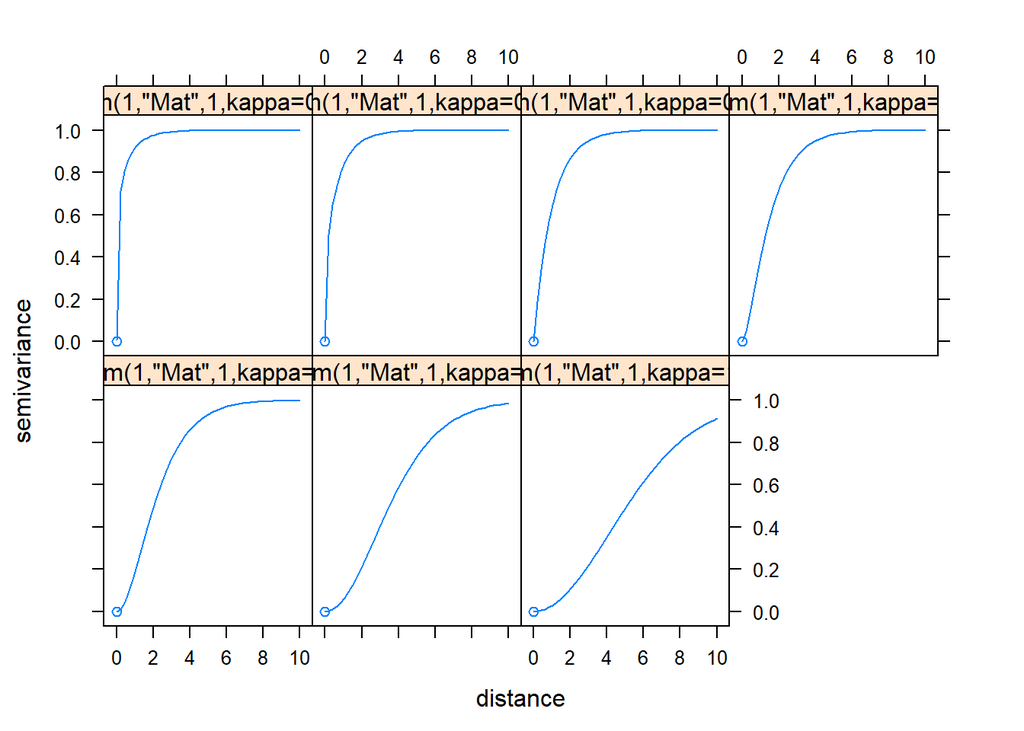

```r
show.vgms(model = "Mat", kappa.range = c(0.1,0.2,0.5,1,2,5,10), max=10) #Matern class models
```

- Valid variogram models are usually constructed by combination of two or more basic variogram models
- Nugget variance reflects usually measurement error or micro-variability.
- `vgm(psill, model, range, psill value of nugget model)`
  - psill: partial sill(vertical extent of the model componenet)
  - range: horizontal extent
- How to construct model:

```r
# example
head(vgm()) # list of models
```

```
##   short                               long
## 1   Nug                       Nug (nugget)
## 2   Exp                  Exp (exponential)
## 3   Sph                    Sph (spherical)
## 4   Gau                     Gau (gaussian)
## 5   Exc Exclass (Exponential class/stable)
## 6   Mat                       Mat (Matern)
```

```r
# Exp, Sph, Gau, Mat, Pow commonly used, with or without nugget
vgm(1, "Sph",300)
```

```
##   model psill range
## 1   Sph     1   300
```

```r
vgm(1, "Sph",300,0.5)
```

```
##   model psill range
## 1   Nug   0.5     0
## 2   Sph   1.0   300
```

```r
v1 <- vgm(1, "Sph",300,0.5)
v2 <- vgm(0.8, "Sph", 800, add.to = v1) # add.to v1
v2
```

```
##   model psill range
## 1   Nug   0.5     0
## 2   Sph   1.0   300
## 3   Sph   0.8   800
```

```r
vgm(0.5, "Nug",0)
```

```
##   model psill range
## 1   Nug   0.5     0
```

- `gstat` uses range <sub>parameters</sub>, for example the exponential model with parital sill $c$ and range parameter $a$:
  $$\gamma(h) = c(1-e^{-h/a}).$$
- can model practial range
- Applying to our data: `fit.variogram` function

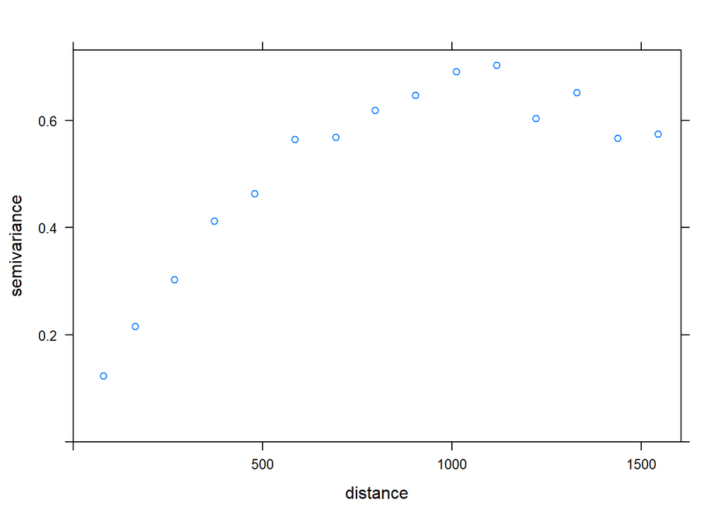

```r
v <- variogram(log(zinc) ~ 1, meuse)
plot(v) # spherical model might be a reasonable choice
```

```r
fit.variogram(v, vgm(1, "Sph", 800,1)) # proper initial value
```

```
##   model      psill    range
## 1   Nug 0.05065923   0.0000
## 2   Sph 0.59060463 896.9976
```

```r
fit.variogram(v, vgm(1, "Sph", 10,1)) # far from reasonable values. #singular model
```

```
##   model psill range
## 1   Nug     1     0
## 2   Sph     1    10
```

- Fitting method uses non-linear regression to fit the coefficients.
- weighted SSE $\sum_{j=1}^{p} w_j (\gamma(h) -\hat{\gamma}(h))^2$
- two optimization steps: (i) fit partial sill(c), (ii) fit range parameter(a)
- There are several weighted mehtod, default is: $N_j / h_j ^2$

#### Visual fitting

```r
# library(geoR)
# v.eye <- eyefit(variog(as.geodata(meuse["zinc"]), max.dist = 1500))
# ve.fit <- as.vgm.variomodel(v.eye[[1]])
```

#### Partial fitting

```r
fit.variogram(v, vgm(1, "Sph", 800, 0.06), fit.sills = c(FALSE, TRUE)) # fitting only "Sph" model
```

```
##   model     psill    range
## 1   Nug 0.0600000   0.0000
## 2   Sph 0.5845836 923.0066
```

#### Maximum likelihood fitting

```r
fit.variogram.reml(log(zinc) ~ 1, meuse, model = vgm(0.6, "Sph", 800, 0.06))
```

```
##   model      psill range
## 1   Nug 0.02006905     0
## 2   Sph 0.57134920   800
```

- optimal under the assumption of Gaussian random field.

#### Directional Variogram fitting

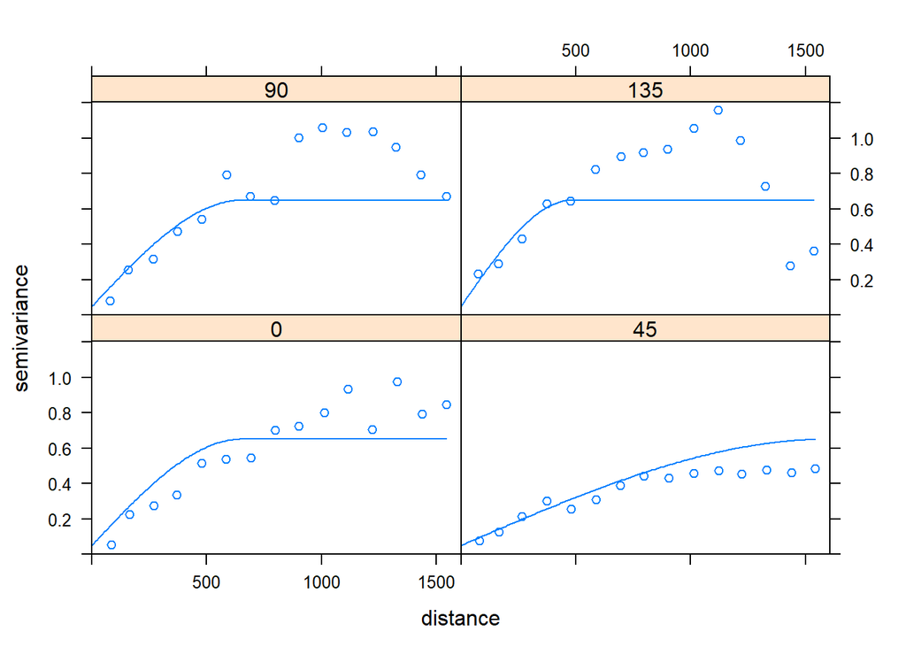

```r
v.dir <- variogram(log(zinc) ~ 1, meuse, alpha = (0:3)*45)
v.anis <- vgm(.6, "Sph", 1600, .05, anis=c(45,.3))
plot(v.dir, v.anis)
```